# Machine Learning

Debaditya Chatterjee

June 21, 2015

### Background

Using devices such as Jawbone Up, Nike FuelBand, and Fitbit it is now possible to collect a large amount of data about personal activity relatively inexpensively. These type of devices are part of the quantified self movement – a group of enthusiasts who take measurements about themselves regularly to improve their health, to find patterns in their behavior, or because they are tech geeks. One thing that people regularly do is quantify how much of a particular activity they do, but they rarely quantify how well they do it. In this project, your goal will be to use data from accelerometers on the belt, forearm, arm, and dumbell of 6 participants. They were asked to perform barbell lifts correctly and incorrectly in 5 different ways. More information is available from the website here: http://groupware.les.inf.puc-rio.br/har (see the section on the Weight Lifting Exercise Dataset).

### Data

The training data for this project are available here:

https://d396qusza40orc.cloudfront.net/predmachlearn/pml-training.csv

The test data are available here:

https://d396qusza40orc.cloudfront.net/predmachlearn/pml-testing.csv

The data for this project come from this source: http://groupware.les.inf.puc-rio.br/har. If you use the document you create for this class for any purpose please cite them as they have been very generous in allowing their data to be used for this kind of assignment.

### Overview

Six young health participants were asked to perform one set of 10 repetitions of the Unilateral Dumbbell Biceps Curl in five different fashions: (Class A) - exactly according to the specification  
(Class B) - throwing the elbows to the front (Class C) - lifting the dumbbell only halfway (Class D) - lowering the dumbbell only halfway (Class E) - throwing the hips to the front

The goal of this project is to predict the manner in which they did the exercise. This is the “classe” variable in the training set.

### Reading the Data

We have set a seed at the beginning to ensure reproducibility of the outcome code. As a first step we will read the two datasets.

```r
set.seed(12345)
setwd("~/Downloads")
dftst <- read.csv("pml-testing.csv", na.strings=c("NA","#DIV/0!", ""))
dftrn <- read.csv("pml-training.csv", na.strings=c("NA","#DIV/0!", ""))
```

In order to apply various machine learning exercise we will need the following packages

```r
library(caret)
library(rattle)
library(randomForest)
```

```r
library(rpart)
library(rpart.plot)
```

### Exploring the training data

As the first step we will take a quick look at the training dataset.

```r
dim(dftrn)
```

```
## [1] 19622   160
```

In order to keep the length of the report reasonable we execute other exploratory commands but we do not print the output.

```r
summary(dftrn)
str(dftrn)
```

We also look at the distribution of the classe variable in the training data set.

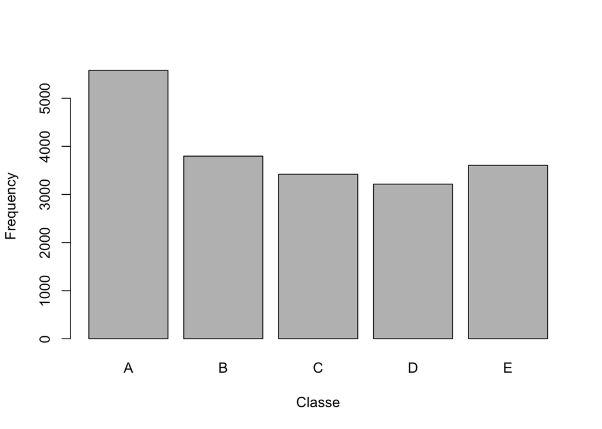

```r
plot(dftrn$classe, xlab="Classe", ylab="Frequency", col="grey")
```

```r
dftrn <- dftrn[,colSums(is.na(dftrn)) == 0]
nz <- nearZeroVar(dftrn, saveMetrics = TRUE)
dftrn <- dftrn[, !nz$nzv]
dftrn <- dftrn[,-(1:6)]
```

Now let us look at the new cleaned up dataframe.

```r
dim(dftrn)
```

```
## [1] 19622    53
```

### Cross Validation

In order to cross validate our model we will split our training data set into two subsets. One for the generating the model and other to test the model. Once the most accurate model is determined we will apply this to the actual test dataset.

```r
inTrain <- createDataPartition(dftrn$classe, p=0.75, list=FALSE)
dftrntrain <- dftrn[inTrain,]
dftrntest <- dftrn[-inTrain,]
dim(dftrntrain)
```

```
## [1] 14718    53
```

```r
dim(dftrntest)
```

```
## [1] 4904   53
```

### Out of sample error

We will use the model accuracy in the cross validation data.Accuracy is determined by the total number of correct predictions against the test dataset genrated from the original datset. Out of sample error is 1 minus accuracy i.e the expected number of misclassified data.

### Model 1 - Classification Tree

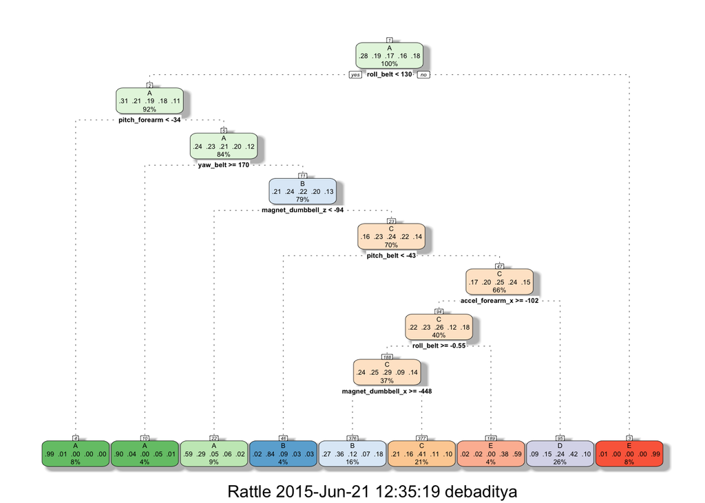

```r
model1 <- train(classe ~., method="rpart", data=dftrntrain)
fancyRpartPlot(model1$finalModel)
```

#### Applying the Model Now we apply the generated model on the same training dataset and check the accuracy.

```r
prediction1 <- predict(model1, dftrntrain)
confusionMatrix(prediction1, dftrntrain$classe)
```

```
## Confusion Matrix and Statistics
##
##           Reference
## Prediction    A    B    C    D    E
##          A 2534  428   62  109   36
##          B  619 1346  340  172  426
##          C  663  499 1277  336  321
##          D  349  564  888 1587  380
##          E   20   11    0  208 1543
##
## Overall Statistics
##
##                Accuracy : 0.5631
##                  95% CI : (0.555, 0.5711)
##     No Information Rate : 0.2843
##     P-Value [Acc > NIR] : < 2.2e-16
##
##                   Kappa : 0.4536
##  Mcnemar's Test P-Value : < 2.2e-16
##
## Statistics by Class:
##
##                      Class: A Class: B Class: C Class: D Class: E
## Sensitivity            0.6055  0.47261  0.49747   0.6580   0.5702
## Specificity            0.9397  0.86883  0.85030   0.8228   0.9801
## Pos Pred Value         0.7996  0.46366  0.41247   0.4212   0.8659
## Neg Pred Value         0.8570  0.87287  0.88900   0.9247   0.9101
## Prevalence             0.2843  0.19350  0.17441   0.1639   0.1839
## Detection Rate         0.1722  0.09145  0.08676   0.1078   0.1048
## Detection Prevalence   0.2153  0.19724  0.21035   0.2560   0.1211
## Balanced Accuracy      0.7726  0.67072  0.67388   0.7404   0.7752
```

We find this to be not very accurate. Let us apply the same model to our test data set generated from the original training set.

```r
prediction2 <- predict(model1, dftrntest)
confusionMatrix(prediction2, dftrntest$classe)
```

```
## Confusion Matrix and Statistics
##
##           Reference
## Prediction   A   B   C   D   E
##          A 859 151  27  43  14
##          B 215 434 117  65 143
##          C 203 166 442 131 111
##          D 109 197 269 492 133
##          E   9   1   0  73 500
##
## Overall Statistics
##
##                Accuracy : 0.5561
##                  95% CI : (0.542, 0.57)
##     No Information Rate : 0.2845
##     P-Value [Acc > NIR] : < 2.2e-16
##
##                   Kappa : 0.4442
##  Mcnemar's Test P-Value : < 2.2e-16
##
## Statistics by Class:
##
##                      Class: A Class: B Class: C Class: D Class: E
## Sensitivity            0.6158   0.4573  0.51696   0.6119   0.5549
## Specificity            0.9330   0.8635  0.84910   0.8273   0.9793
## Pos Pred Value         0.7852   0.4456  0.41975   0.4100   0.8576
## Neg Pred Value         0.8593   0.8690  0.89276   0.9158   0.9072
## Prevalence             0.2845   0.1935  0.17435   0.1639   0.1837
## Detection Rate         0.1752   0.0885  0.09013   0.1003   0.1020
## Detection Prevalence   0.2231   0.1986  0.21472   0.2447   0.1189
## Balanced Accuracy      0.7744   0.6604  0.68303   0.7196   0.7671
```

This model has an accuracy of only about 55%. We should look at another better model.

### Model 2: Random Forest

We will generate another model using the Random Forest machine learning algorithm and then validate the test set (generated from our training set).

```r
model2 <- randomForest(classe ~. , data=dftrntrain, method=class)
prediction3 <- predict(model2, dftrntest)
confusionMatrix(prediction3, dftrntest$classe)
```

```
## Confusion Matrix and Statistics
##
##           Reference
## Prediction    A    B    C    D    E
##          A 1395    8    0    0    0
##          B    0  937    2    0    0
##          C    0    4  852    3    0
##          D    0    0    1  801    1
##          E    0    0    0    0  900
##
## Overall Statistics
##
##                Accuracy : 0.9961
##                  95% CI : (0.994, 0.9977)
##     No Information Rate : 0.2845
##     P-Value [Acc > NIR] : < 2.2e-16
##
##                   Kappa : 0.9951
##  Mcnemar's Test P-Value : NA
##
## Statistics by Class:
##
##                      Class: A Class: B Class: C Class: D Class: E
## Sensitivity            1.0000   0.9874   0.9965   0.9963   0.9989
## Specificity            0.9977   0.9995   0.9983   0.9995   1.0000
## Pos Pred Value         0.9943   0.9979   0.9919   0.9975   1.0000
## Neg Pred Value         1.0000   0.9970   0.9993   0.9993   0.9998
## Prevalence             0.2845   0.1935   0.1743   0.1639   0.1837
## Detection Rate         0.2845   0.1911   0.1737   0.1633   0.1835
## Detection Prevalence   0.2861   0.1915   0.1752   0.1637   0.1835
## Balanced Accuracy      0.9989   0.9934   0.9974   0.9979   0.9994
```

We can see this model has very high accuracy (over 99%) and hence very little out of sample errors. Hence we will use the random forest model and apply this to our original test dataset.

```r
Final <- predict(model2, dftst)
Final
```

```
##  1  2  3  4  5  6  7  8  9 10 11 12 13 14 15 16 17 18 19 20
##  B  A  B  A  A  E  D  B  A  A  B  C  B  A  E  E  A  B  B  B
## Levels: A B C D E
```